# Predicting daily Citibike trips (open-ended)

Basira Shirzad

’2020-06-18 16:42:20

# Setup

Load some packages to help us model our data

```r
library(tidyverse)
library(scales)
library(modelr)
library(lubridate)
```

```r
# set plot theme
theme_set(theme_bw())
options(repr.plot.width=4, repr.plot.height=3)
knitr::opts_chunk$set(echo = TRUE)
```

# Load and preview data

Read data from the `trips_per_day.tsv` file

```r
trips_per_day <- read_tsv('trips_per_day.tsv')
head(trips_per_day)
```

| ymd | num_trips | date | prcp | snwd | snow | tmax | tmin |
| --- | --- | --- | --- | --- | --- | --- | --- |
| 2014-01-01 | 6059 | 20140101 | 0.00 | 0.0 | 0.0 | 3.3 | 2.4 |
| 2014-01-02 | 8600 | 20140102 | 0.33 | 0.0 | 3.1 | 3.3 | 1.8 |
| 2014-01-03 | 1144 | 20140103 | 0.29 | 5.9 | 3.3 | 1.8 | 0.9 |
| 2014-01-04 | 2292 | 20140104 | 0.00 | 5.9 | 0.0 | 2.9 | 0.8 |
| 2014-01-05 | 2678 | 20140105 | 0.14 | 3.9 | 0.0 | 4.0 | 2.7 |
| 2014-01-06 | 9510 | 20140106 | 0.36 | 1.2 | 0.0 | 5.5 | 1.9 |

Read data from the `US_Bank_holidays` file

```r
holidays <- read_csv('US_Bank_holidays', col_names = c('day_num', 'ymd', 'holiday_name'))
head(holidays)
```

| day_num | ymd | holiday_name |
| --- | --- | --- |
| 1 | 2012-01-02 | New Year Day |
| 2 | 2012-01-16 | Martin Luther King Jr. Day |
| 3 | 2012-02-20 | Presidents Day (Washingtons Birthday) |
| 4 | 2012-05-28 | Memorial Day |
| 5 | 2012-07-04 | Independence Day |
| 6 | 2012-09-03 | Labor Day |

Create a model_data frame that includes information from both files

```r
model_data <- trips_per_day %>%
  mutate(day = as.factor(wday(ymd, label = F)), is_weekday = between(wday(ymd),2,6), is_rain = prcp > 0) %>%
  left_join(holidays) %>%
  mutate(is_holiday = !is.na(holiday_name)) %>%
  select(ymd, num_trips, prcp, tmax, tmin, day, is_weekday, is_rain, is_holiday)
head(model_data)
```

| ymd | num_trips | prcp | tmax | tmin | day | is_weekday | is_rain | is_holiday |
| --- | --- | --- | --- | --- | --- | --- | --- | --- |
| 2014-01-01 | 6059 | 0.00 | 3.3 | 2.4 | 4 | TRUE | FALSE | TRUE |
| 2014-01-02 | 8600 | 0.33 | 3.3 | 1.8 | 5 | TRUE | TRUE | FALSE |
| 2014-01-03 | 1144 | 0.29 | 1.8 | 0.9 | 6 | TRUE | TRUE | FALSE |
| 2014-01-04 | 2292 | 0.00 | 2.9 | 0.8 | 7 | FALSE | FALSE | FALSE |
| 2014-01-05 | 2678 | 0.14 | 4.0 | 2.7 | 1 | FALSE | TRUE | FALSE |
| 2014-01-06 | 9510 | 0.36 | 5.5 | 1.9 | 2 | TRUE | TRUE | FALSE |

# Plot Graph

Plot for the number of trips taken as a function of the minimum temperature on each day.

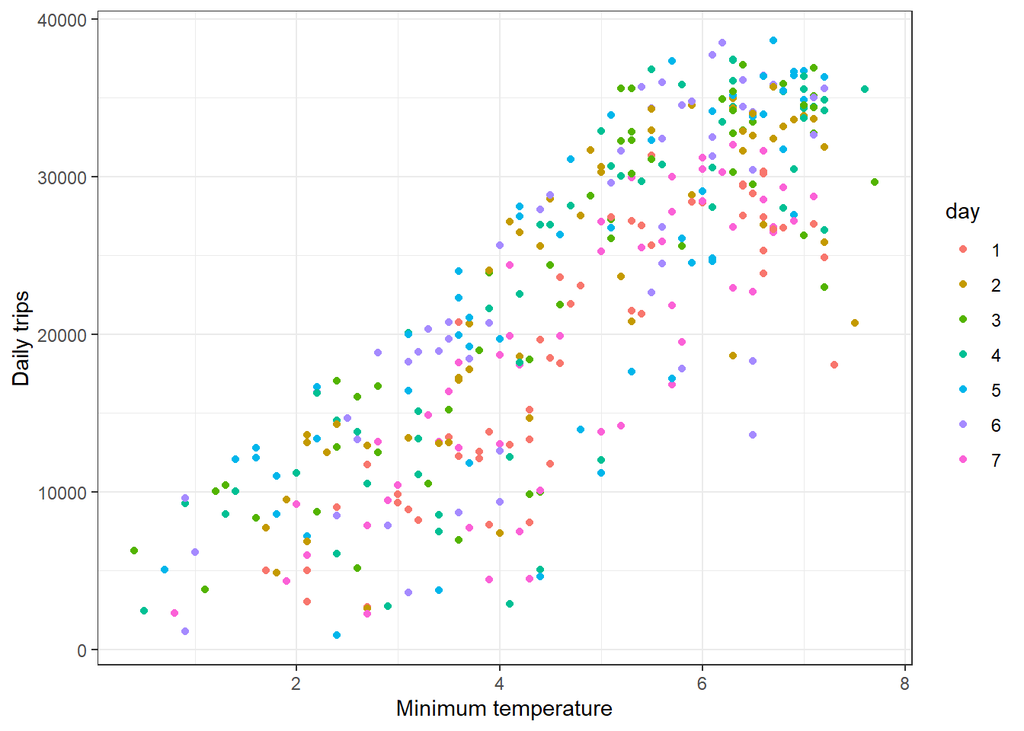

```r
ggplot(model_data, aes(x = tmin, y = num_trips)) +
  geom_point(aes(colour = day)) +
  xlab('Minimum temperature') +
  ylab('Daily trips') +
  scale_y_continuous()
```

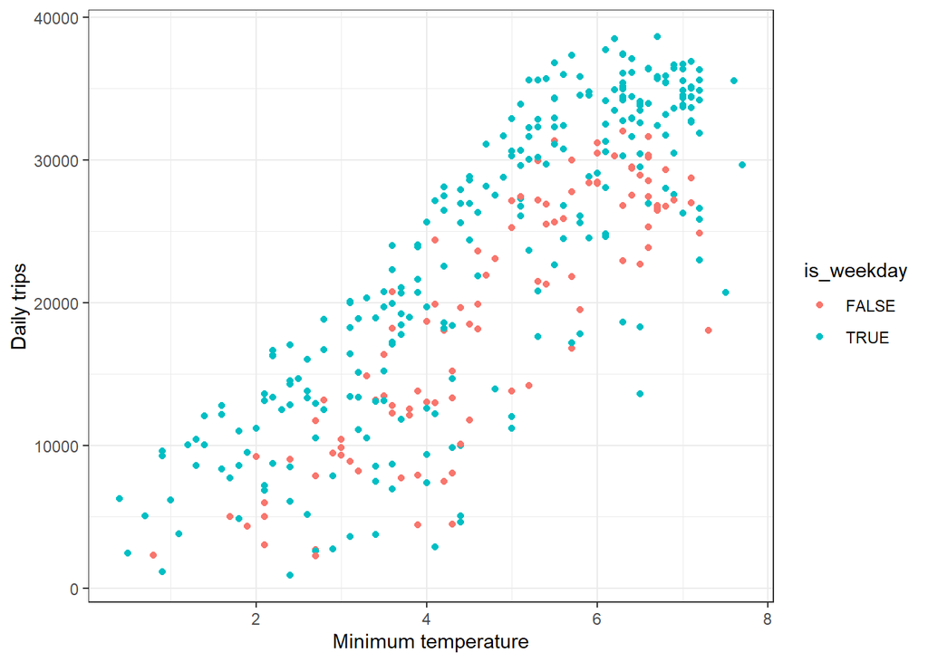

```r
ggplot(model_data, aes(x = tmin, y = num_trips)) +
  geom_point(aes(colour = is_weekday)) +
  xlab('Minimum temperature') +
  ylab('Daily trips') +
  scale_y_continuous()
```

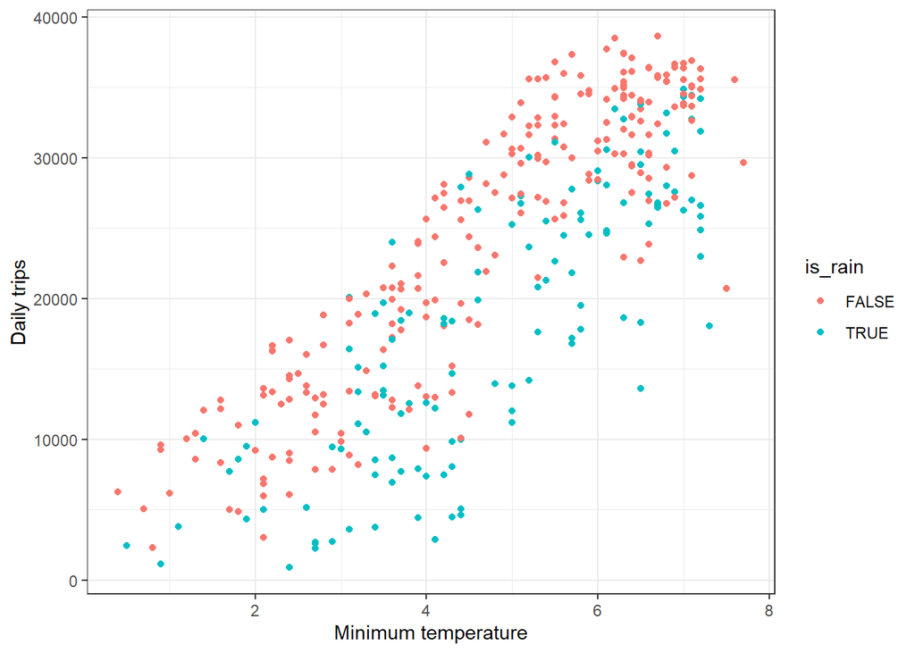

```r
ggplot(model_data, aes(x = tmin, y = num_trips)) +
  geom_point(aes(colour = is_rain)) +
  xlab('Minimum temperature') +
  ylab('Daily trips') +
  scale_y_continuous()
```

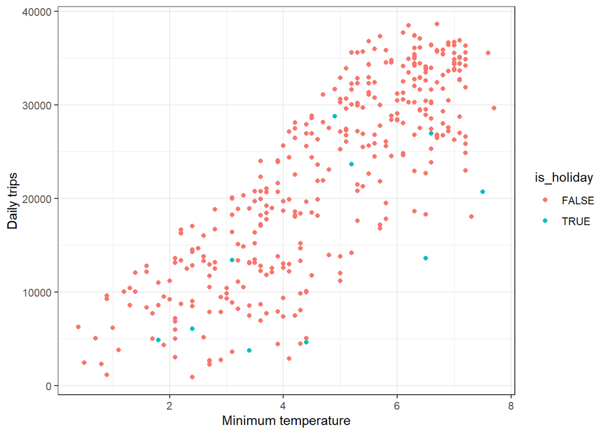

```r
ggplot(model_data, aes(x = tmin, y = num_trips)) +
  geom_point(aes(colour = is_holiday)) +
  xlab('Minimum temperature') +
  ylab('Daily trips') +
  scale_y_continuous()
```

Plot for the number of trips taken as a function of the maximum temperature on each day.

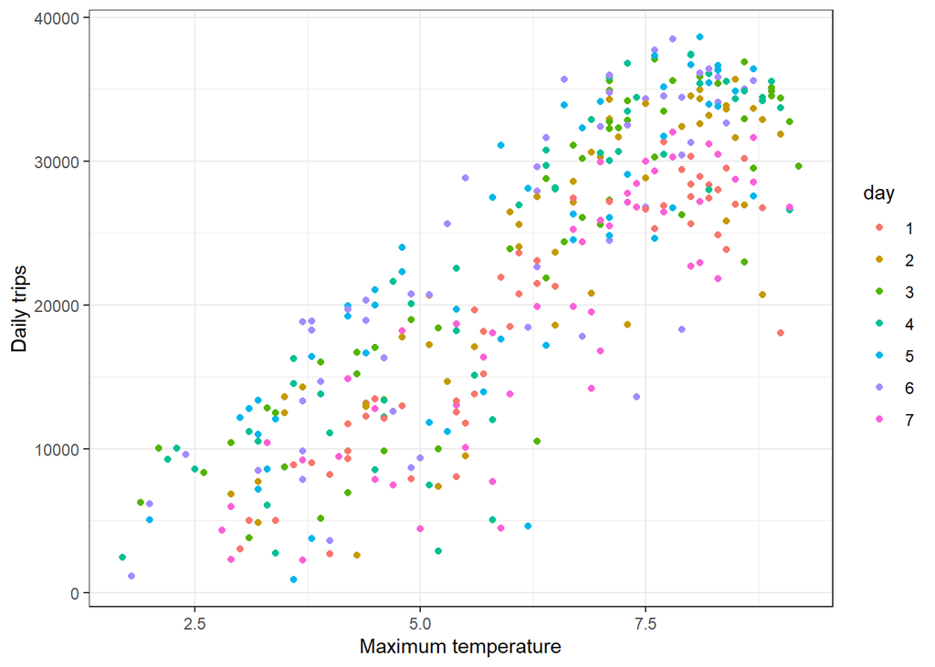

```r
ggplot(model_data, aes(x = tmax, y = num_trips)) +
  geom_point(aes(colour = day)) +
  xlab('Maximum temperature') +
  ylab('Daily trips') +
  scale_y_continuous()
```

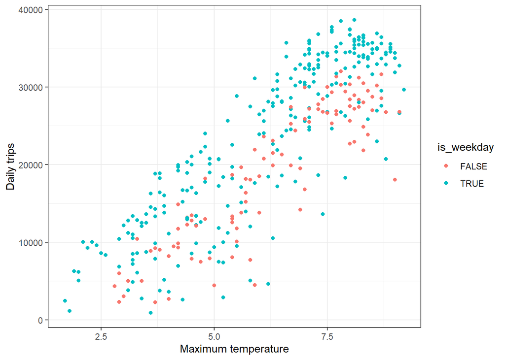

```r
ggplot(model_data, aes(x = tmax, y = num_trips)) +
  geom_point(aes(colour = is_weekday)) +
  xlab('Maximum temperature') +
  ylab('Daily trips') +
  scale_y_continuous()
```

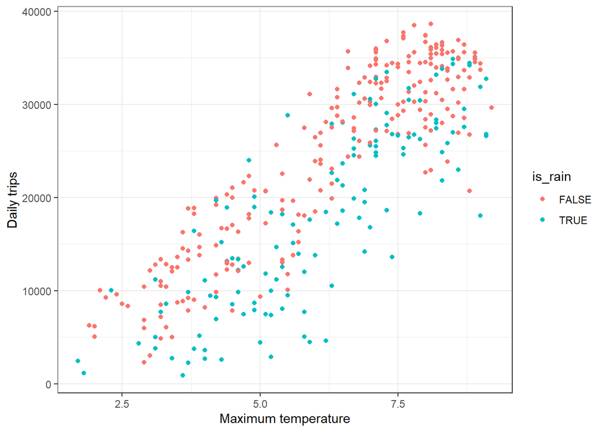

```r
ggplot(model_data, aes(x = tmax, y = num_trips)) +
  geom_point(aes(colour = is_rain)) +
  xlab('Maximum temperature') +
  ylab('Daily trips') +
  scale_y_continuous()
```

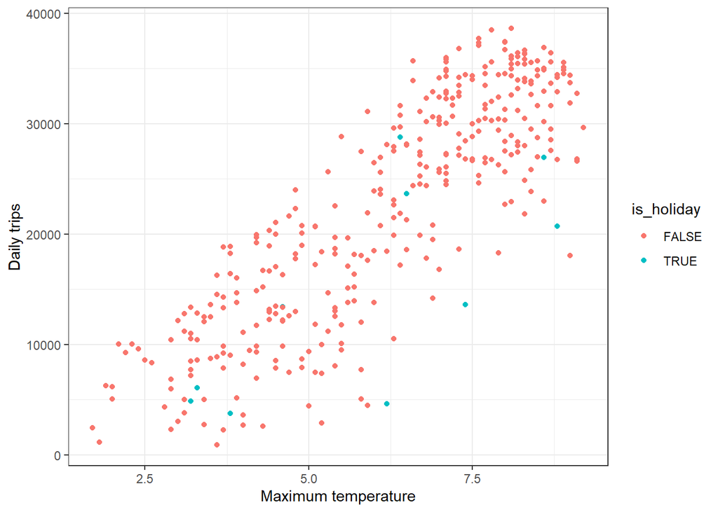

```r
ggplot(model_data, aes(x = tmax, y = num_trips)) +
  geom_point(aes(colour = is_holiday)) +
  xlab('Maximum temperature') +
  ylab('Daily trips') +
  scale_y_continuous()
```

# Cross-validation

Fitting different polynomials to the data and using cross-validation (shuffled data and used 80% of the data for training and 10% of the data for validation) to find the polynomial degree that generalizes best to held out data.

```r
# Random number generator that produces the same sequence of numbers
set.seed(42)

num_days <- nrow(model_data)
frac_train <- 0.8 # train on 80% of the data
num_train <- floor(num_days * frac_train)

# randomly sample rows for the training set
ndx <- sample(1:num_days, num_train, replace=F)

# used to fit the model
trips_per_day_train <- model_data[ndx, ]

# used to evaluate the fit
trips_per_day_remaining <- model_data[-ndx, ]
num_remaining = floor(nrow(trips_per_day_remaining)/2)

ndx2 <- sample(1:nrow(trips_per_day_remaining), num_remaining, replace = F)
trips_per_day_validate <- trips_per_day_remaining[ndx2, ]
trips_per_day_test <- trips_per_day_remaining[-ndx2, ]
```

# Evaluation

Evaluating models from degree 1 to degree 8, fitting on the training data and evaluate on the validation data.

```r
# fit a model for each polynomial degree
K <- 1:8
train_err <- c()
validate_err <- c()
for (k in K) {

    # fit on the training data
    model <- lm(num_trips ~ poly(tmin, k, raw = T) + poly(tmax, k, raw = T) + day + is_weekday + is_rain + is_holiday, data=trips_per_day_train)

    # evaluate on the training data
    train_err[k] <- sqrt(mean((predict(model, trips_per_day_train) - trips_per_day_train$num_trips)^2))

    # evaluate on the validate data
    validate_err[k] <- sqrt(mean((predict(model, trips_per_day_validate) - trips_per_day_validate$num_trips)^2))
}
summary(model)
```

```
##
## Call:
## lm(formula = num_trips ~ poly(tmin, k, raw = T) + poly(tmax,
##     k, raw = T) + day + is_weekday + is_rain + is_holiday, data = trips_per_day_train)
##
## Residuals:
##      Min       1Q   Median       3Q      Max
## -13107.8  -1549.0    155.3   1805.9  10159.5
##
## Coefficients: (1 not defined because of singularities)
##                           Estimate Std. Error t value Pr(>|t|)
## (Intercept)             -1.025e+06  4.437e+05  -2.311  0.02160 *
## poly(tmin, k, raw = T)1  8.921e+03  6.510e+04   0.137  0.89110
## poly(tmin, k, raw = T)2 -4.371e+03  9.148e+04  -0.048  0.96193
## poly(tmin, k, raw = T)3 -1.892e+03  6.451e+04  -0.029  0.97662
## poly(tmin, k, raw = T)4  2.507e+03  2.558e+04   0.098  0.92200
## poly(tmin, k, raw = T)5 -9.019e+02  5.955e+03  -0.151  0.87973
## poly(tmin, k, raw = T)6  1.519e+02  8.069e+02   0.188  0.85083
## poly(tmin, k, raw = T)7 -1.233e+01  5.887e+01  -0.209  0.83429
## poly(tmin, k, raw = T)8  3.874e-01  1.788e+00   0.217  0.82858
## poly(tmax, k, raw = T)1  2.035e+06  8.443e+05   2.411  0.01660 *
## poly(tmax, k, raw = T)2 -1.678e+06  6.620e+05  -2.534  0.01183 *
## poly(tmax, k, raw = T)3  7.496e+05  2.842e+05   2.637  0.00885 **
## poly(tmax, k, raw = T)4 -1.988e+05  7.334e+04  -2.710  0.00715 **
## poly(tmax, k, raw = T)5  3.216e+04  1.168e+04   2.753  0.00631 **
## poly(tmax, k, raw = T)6 -3.110e+03  1.125e+03  -2.766  0.00608 **
## poly(tmax, k, raw = T)7  1.651e+02  6.001e+01   2.752  0.00633 **
## poly(tmax, k, raw = T)8 -3.700e+00  1.362e+00  -2.716  0.00703 **
## day2                     4.228e+03  7.792e+02   5.425 1.30e-07 ***
## day3                     4.667e+03  8.125e+02   5.744 2.52e-08 ***
## day4                     6.553e+03  7.828e+02   8.372 3.23e-15 ***
## day5                     6.288e+03  7.607e+02   8.265 6.59e-15 ***
## day6                     5.184e+03  8.047e+02   6.442 5.46e-10 ***
## day7                    -3.111e+02  7.727e+02  -0.403  0.68759
## is_weekdayTRUE                  NA         NA      NA       NA
## is_rainTRUE             -5.761e+03  4.478e+02 -12.864  < 2e-16 ***
## is_holidayTRUE          -8.465e+03  1.273e+03  -6.649 1.66e-10 ***
## ---
## Signif. codes:  0 '***' 0.001 '**' 0.01 '*' 0.05 '.' 0.1 ' ' 1
##
## Residual standard error: 3450 on 267 degrees of freedom
## Multiple R-squared:  0.8984, Adjusted R-squared:  0.8893
## F-statistic: 98.37 on 24 and 267 DF,  p-value: < 2.2e-16
```

Plot for the training and validation error as a function of the polynomial degree.

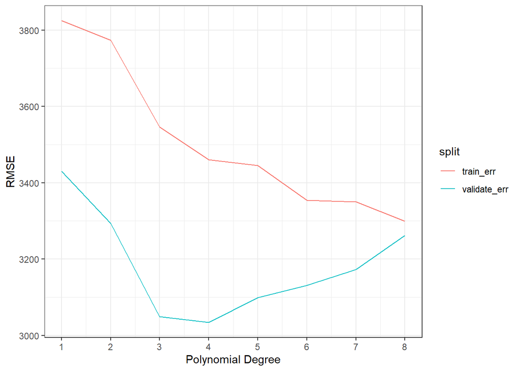

```r
plot_data <- data.frame(K, train_err, validate_err) %>%
  gather("split", "error", -K)

ggplot(plot_data, aes(x=K, y=error, color=split)) +
  geom_line() +
  scale_x_continuous(breaks=K) +
  xlab('Polynomial Degree') +
  ylab('RMSE')
```

Fitting and plotting the model on all of the data

```r
# chose final k
k = 4
model <- lm(num_trips ~ poly(tmin, k, raw = T) + poly(tmax, k, raw = T) + day + is_weekday + is_rain + is_holiday, data=trips_per_day_train)

trips_per_day_train <- trips_per_day_train %>%
  add_predictions(model) %>%
  mutate(split = "train")
trips_per_day_validate <- trips_per_day_validate %>%
  add_predictions(model) %>%
  mutate(split = "validate")
```

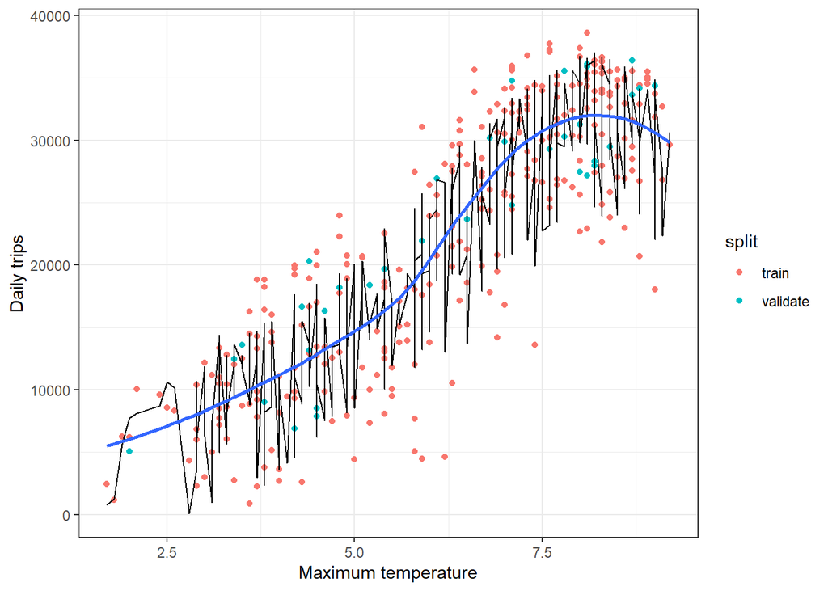

```r
plot_data <- bind_rows(trips_per_day_train, trips_per_day_validate)

ggplot(plot_data, aes(x = tmax, y = num_trips)) +
  geom_point(aes(color = split)) +
  geom_line(aes(y = pred)) +
  geom_smooth(se = FALSE) +
  xlab('Maximum temperature') +
  ylab('Daily trips') +
  scale_y_continuous()
```

```r
rsquare(model, plot_data)
```

```
## [1] 0.8893978
```

```r
rmse(model, plot_data)
```

```
## [1] 3416.172
```

# Re-Evaluating

Re-evaluating models from degree 1 to degree 8, fitting on the training data and evaluate on the validation data.

```r
# fit a model for each polynomial degree
K <- 1:8
train_err <- c()
validate_err <- c()
for (k in K) {

    # fit on the training data
    model <- lm(num_trips ~ poly(tmax, k, raw = T) + day + is_rain + is_holiday, data=trips_per_day_train)

    # evaluate on the training data
    train_err[k] <- sqrt(mean((predict(model, trips_per_day_train) - trips_per_day_train$num_trips)^2))

    # evaluate on the validate data
    validate_err[k] <- sqrt(mean((predict(model, trips_per_day_validate) - trips_per_day_validate$num_trips)^2))
}

summary(model)
```

```
##
## Call:
## lm(formula = num_trips ~ poly(tmax, k, raw = T) + day + is_rain +
##     is_holiday, data = trips_per_day_train)
##
## Residuals:
##    Min     1Q Median     3Q    Max
## -12967  -1640    329   1966  10303
##
## Coefficients:
##                           Estimate Std. Error t value Pr(>|t|)
## (Intercept)             -1.133e+06  4.193e+05  -2.703  0.00730 **
## poly(tmax, k, raw = T)1  2.235e+06  7.881e+05   2.836  0.00491 **
## poly(tmax, k, raw = T)2 -1.825e+06  6.172e+05  -2.956  0.00339 **
## poly(tmax, k, raw = T)3  8.079e+05  2.644e+05   3.056  0.00246 **
## poly(tmax, k, raw = T)4 -2.126e+05  6.799e+04  -3.127  0.00196 **
## poly(tmax, k, raw = T)5  3.416e+04  1.079e+04   3.166  0.00172 **
## poly(tmax, k, raw = T)6 -3.287e+03  1.035e+03  -3.177  0.00166 **
## poly(tmax, k, raw = T)7  1.739e+02  5.501e+01   3.162  0.00174 **
## poly(tmax, k, raw = T)8 -3.890e+00  1.244e+00  -3.126  0.00196 **
## day2                     3.908e+03  7.642e+02   5.115 5.90e-07 ***
## day3                     4.503e+03  8.080e+02   5.573 5.96e-08 ***
## day4                     6.441e+03  7.780e+02   8.279 5.44e-15 ***
## day5                     6.276e+03  7.529e+02   8.335 3.73e-15 ***
## day6                     5.293e+03  7.969e+02   6.642 1.65e-10 ***
## day7                    -3.761e+02  7.665e+02  -0.491  0.62409
## is_rainTRUE             -5.585e+03  4.362e+02 -12.805  < 2e-16 ***
## is_holidayTRUE          -8.433e+03  1.263e+03  -6.676 1.35e-10 ***
## ---
## Signif. codes:  0 '***' 0.001 '**' 0.01 '*' 0.05 '.' 0.1 ' ' 1
##
## Residual standard error: 3463 on 275 degrees of freedom
## Multiple R-squared:  0.8946, Adjusted R-squared:  0.8885
## F-statistic: 145.9 on 16 and 275 DF,  p-value: < 2.2e-16
```

Re-Plot for the training and validation error as a function of the polynomial degree.

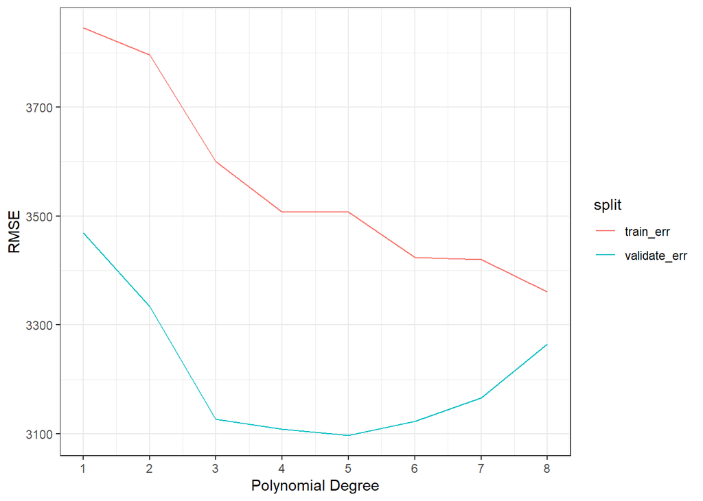

```r
plot_data <- data.frame(K, train_err, validate_err) %>%
  gather("split", "error", -K)

ggplot(plot_data, aes(x=K, y=error, color=split)) +
  geom_line() +
  scale_x_continuous(breaks=K) +
  xlab('Polynomial Degree') +
  ylab('RMSE')
```

Re-fitting and plotting the model on all of the data

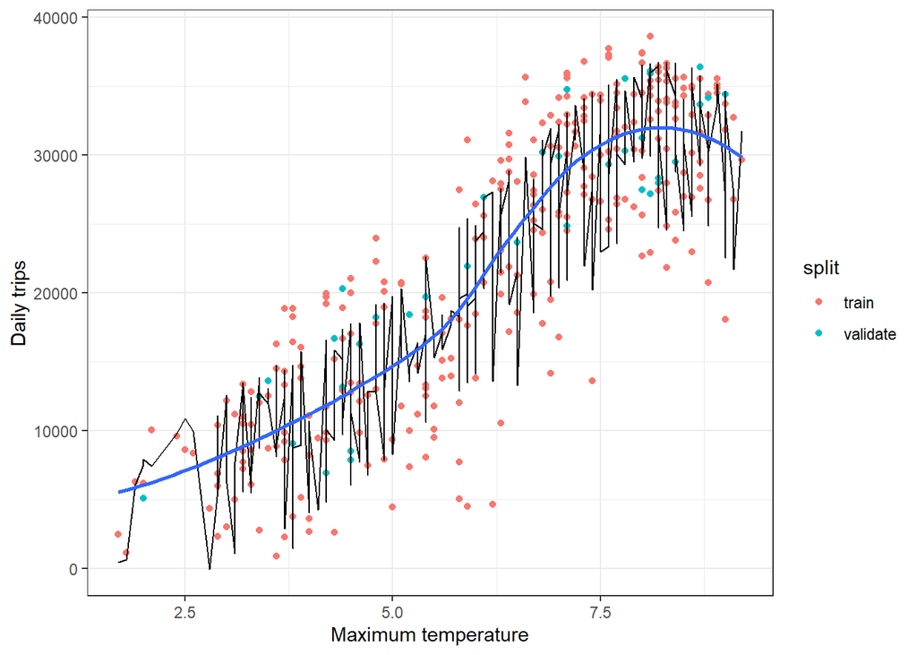

```r
# chose final k
k = 5
model <- lm(num_trips ~ poly(tmax, k, raw = T) + day + is_rain + is_holiday, data=trips_per_day_train)

trips_per_day_train <- trips_per_day_train %>%
  add_predictions(model) %>%
  mutate(split = "train")
trips_per_day_validate <- trips_per_day_validate %>%
  add_predictions(model) %>%
  mutate(split = "validate")
plot_data <- bind_rows(trips_per_day_train, trips_per_day_validate)

ggplot(plot_data, aes(x = tmax, y = num_trips)) +
  geom_point(aes(color = split)) +
  geom_line(aes(y = pred)) +
  geom_smooth(se = FALSE) +
  xlab('Maximum temperature') +
  ylab('Daily trips') +
  scale_y_continuous()
```

```r
rsquare(model, plot_data)
```

```
## [1] 0.8862579
```

```r
rmse(model, plot_data)
```

```
## [1] 3464.335
```

# Final Best Fit Model

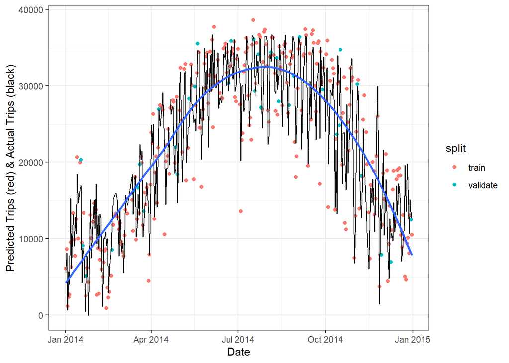

```r
ggplot(plot_data, aes(x = ymd, y = num_trips)) +
  geom_point(aes(color = split)) +
  geom_line(aes(y = pred)) +
  geom_smooth(se = FALSE) +
  xlab('Date') +
  ylab('Predicted Trips (red) & Actual Trips (black)') +
  scale_y_continuous()
```

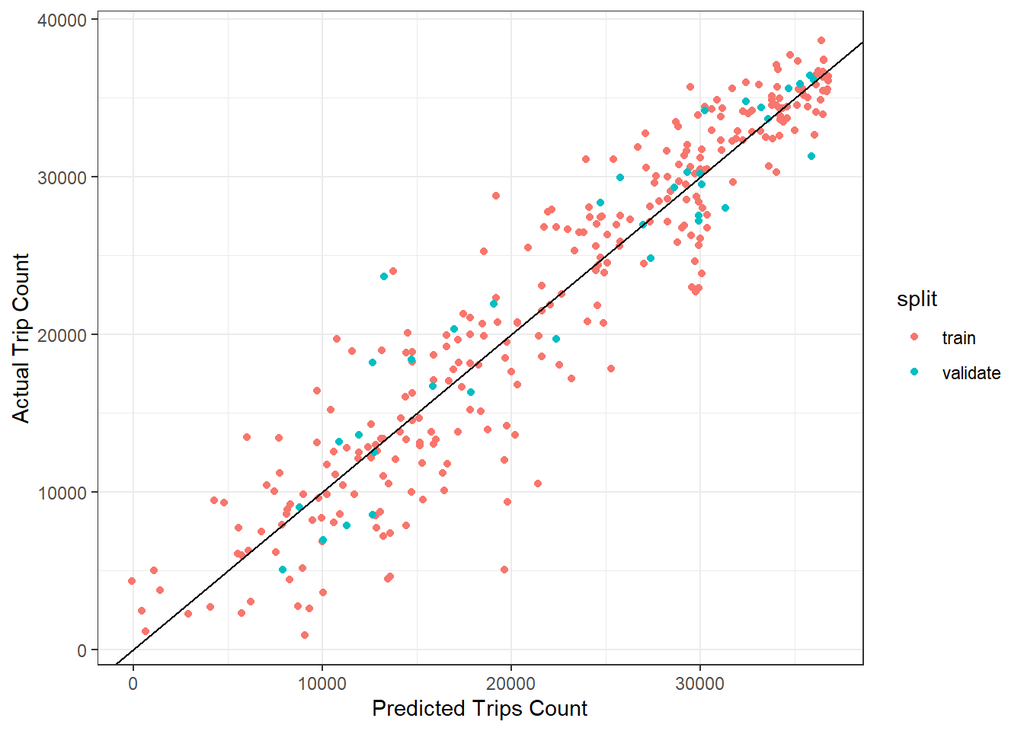

```r
ggplot(plot_data, aes(x = pred, y = num_trips)) +
  geom_point(aes(color = split)) +
  geom_abline() +
  xlab('Predicted Trips Count') +
  ylab('Actual Trip Count') +
  scale_y_continuous()
```

# Testing on Test Data

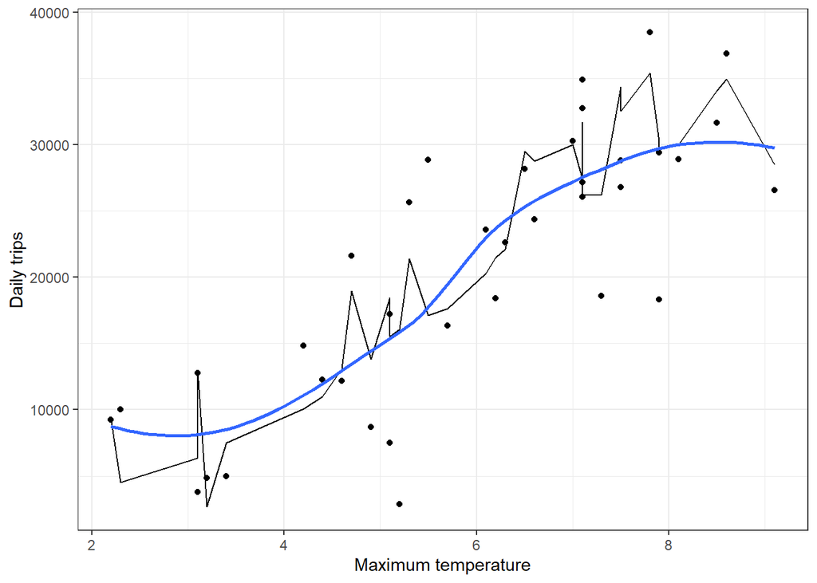

```r
final_model = model

trips_per_day_test <- trips_per_day_test %>%
  add_predictions(final_model)

ggplot(trips_per_day_test, aes(x = tmax, y = num_trips)) +
  geom_point() +
  geom_line(aes(y = pred)) +
  geom_smooth(se = FALSE) +
  xlab('Maximum temperature') +
  ylab('Daily trips') +
  scale_y_continuous()
```

```r
# Results
rsquare(final_model, trips_per_day_test)
```

```
## [1] 0.7590743
```

```r
rmse(final_model, trips_per_day_test)
```

```
## [1] 4918.41
```

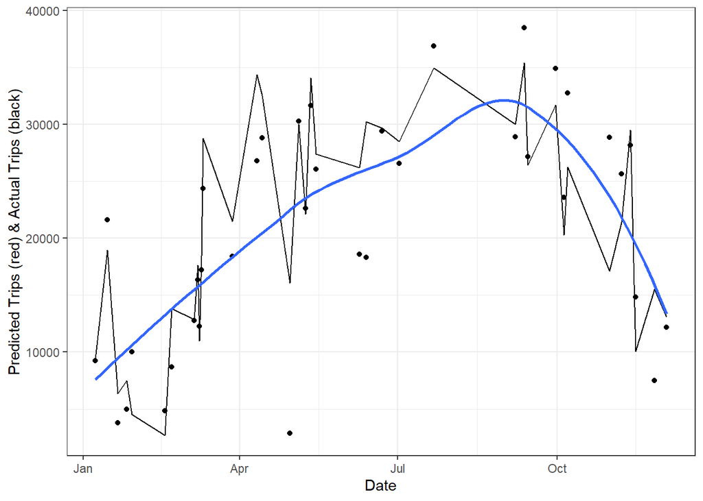

```r
ggplot(trips_per_day_test, aes(x = ymd, y = num_trips)) +
  geom_point() +
  geom_line(aes(y = pred)) +
  geom_smooth(se = FALSE) +
  xlab('Date') +
  ylab('Predicted Trips (red) & Actual Trips (black)') +
  scale_y_continuous()
```

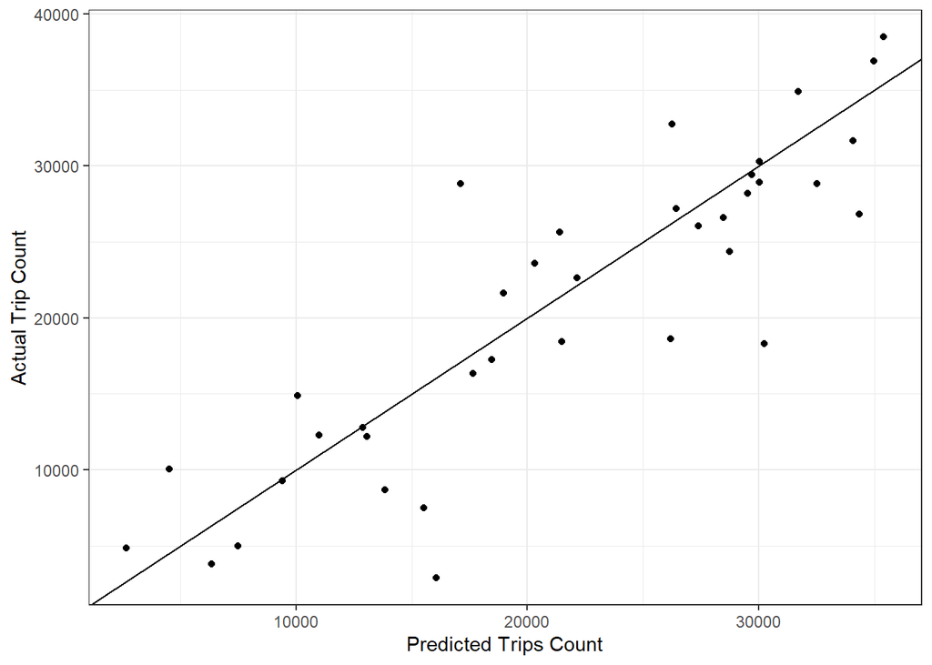

```r
ggplot(trips_per_day_test, aes(x = pred, y = num_trips)) +
  geom_point() +
  geom_abline() +
  xlab('Predicted Trips Count') +
  ylab('Actual Trip Count') +
  scale_y_continuous()
```

```r
# save(final_model, file = "mod.RData")
```